# Visualización de datos

Sesión 1

Luis F. Gomez L.

luis.gomezl@unimilitar.edu.co

Facultad de Estudios a Distancia

2026-09-10

# Preliminares

- Descargar datos: `2021-2024_saber-pro-genericas_faedis.rds`
- Generar carpetas:
  - `data`
    - Agregar `2021-2024_saber-pro-genericas_faedis.rds`
  - `006_visualizar-cantidades-en-r`
    - Crear archivo `001_visualizar-cantidades-datos-faedis.R`
  - `007_visualizar-distribuciones-en-r`
    - Crear archivo `001_visualizar-distribuciones-datos-faedis.R`

# Gramática de gráficos en capas

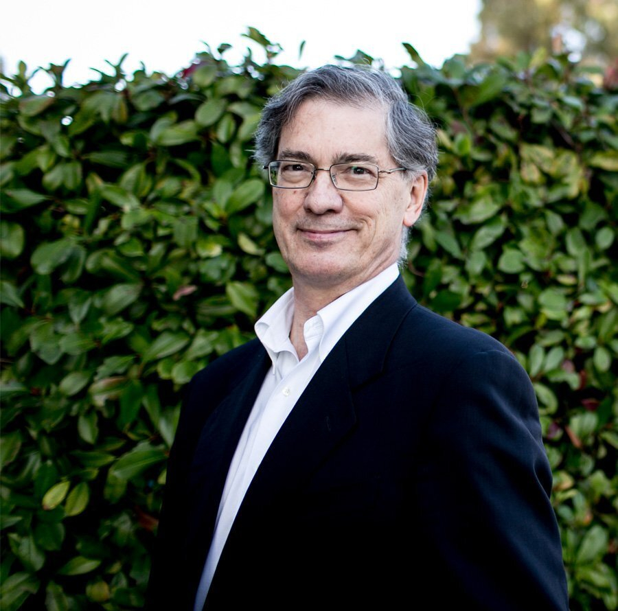

(a) Leland Wilkinson - Gramática de gráficos (Wilkinson y Wills 2005)

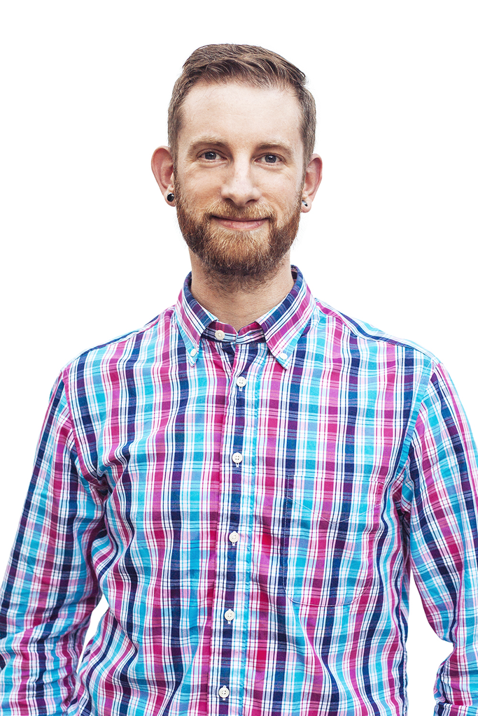

(b) Hadley Wickham - Implementación en R (`ggplot2`)

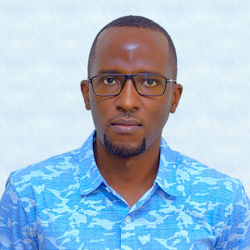

(c) Hassan Kibirige - Implementación en Python (`plotnine`)

Figura 1: Figuras clave en la gramática de gráficos

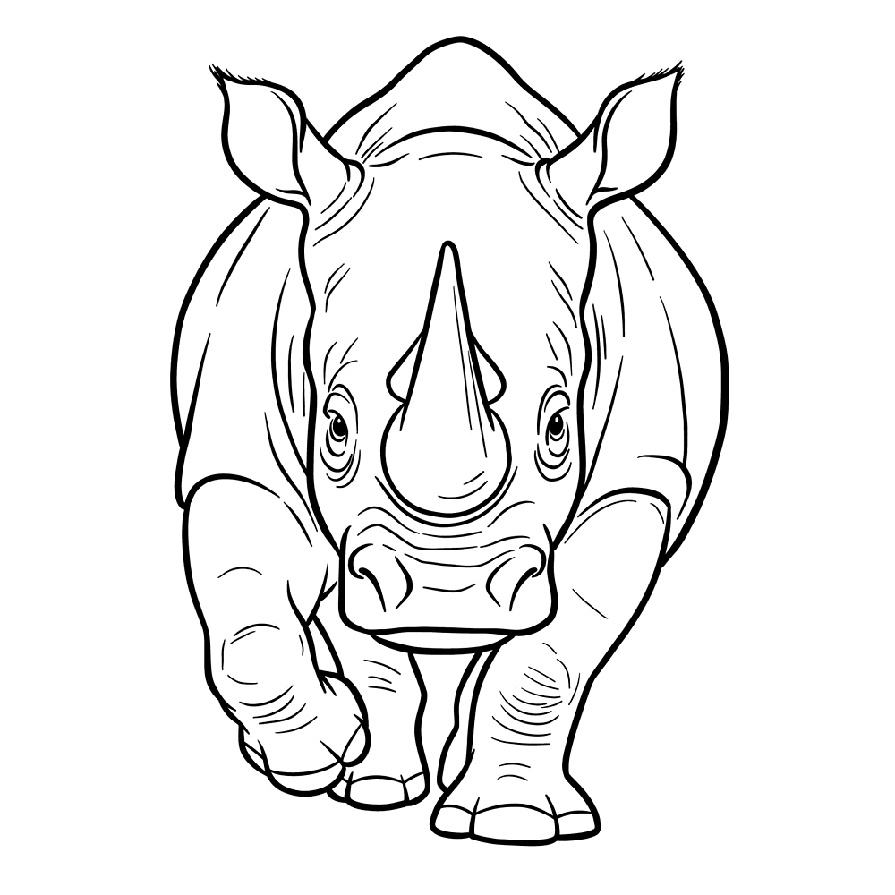

(a) Resulto final

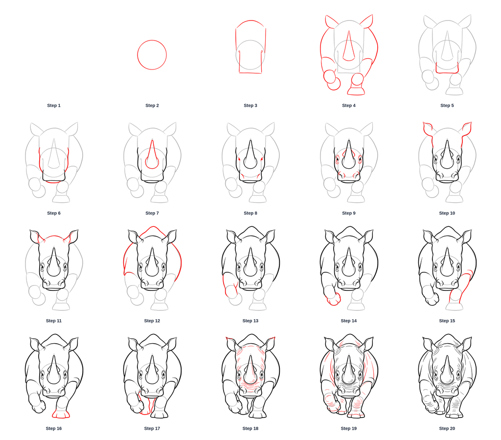

(b) Proceso paso por paso

Figura 2: Dibujando un rinoceronte paso a paso (Khayrullin 2026)

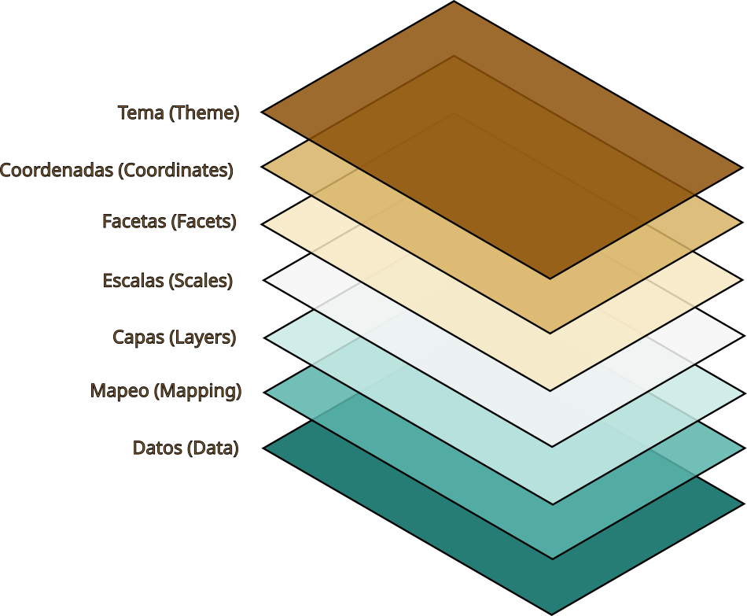

Figura 3: Modelo mental de la gramática de gráficos en capas

- `ggplot2` requiere como mínimo 3 componentes:
  - Datos: insumo principal.
  - Mapeo: mapear variables de los datos a propiedades visuales denominadas **atributos estéticos** (ver Figura 4).
  - Capas: toma los datos mapeados y los transforma en una presentación visual.
    - **geometría**
    - **transformación estadística**
    - **ajuste de posición**
- Los demás elementos restantes cuentan con valores predeterminados.

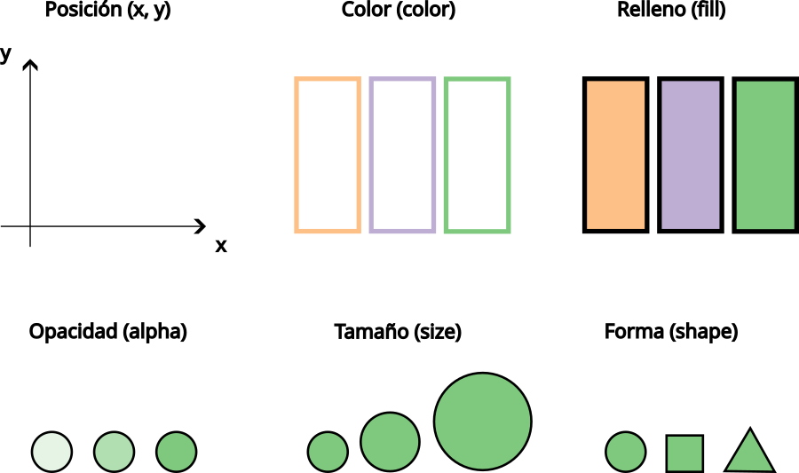

Figura 4: Ejemplos de atributos estéticos

# Gráfico de barras mediante conteo automático

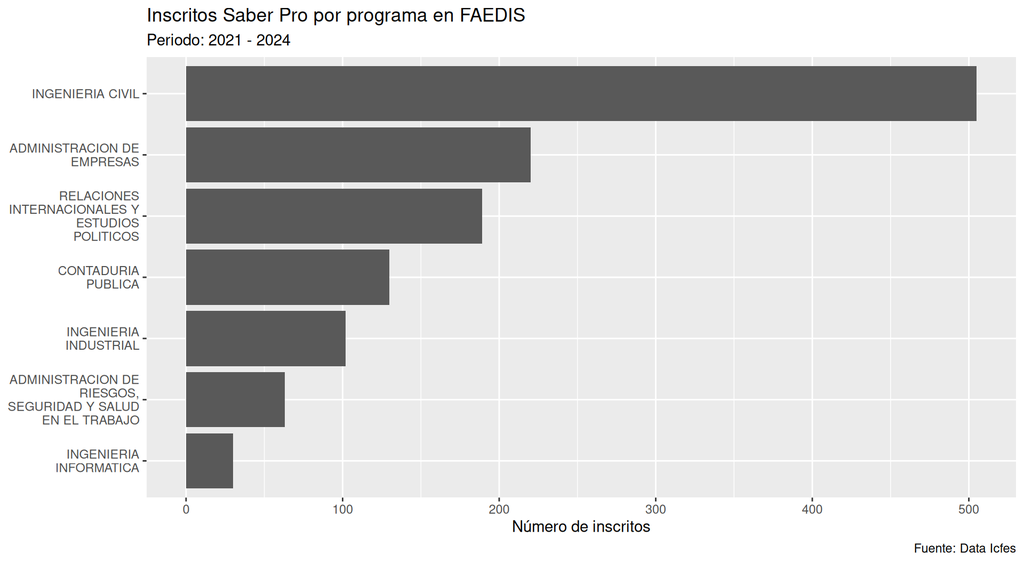

Figura 5: Resultado final de un gráfico de barras utilizando `ggplot2`

## Datos

```r
# Cargar paquetes ----
library(tidyverse)

# Importar datos ----
saber_pro_genericas_faedis_2021_2024 <- read_rds(
  file = "data/2021-2024_saber-pro-genericas_faedis.rds"
)

# Inspeccionar datos ----
glimpse(saber_pro_genericas_faedis_2021_2024)
```

```
Rows: 1,239
Columns: 21
$ ano                         <int> 2021, 2021, 2021, 2021, 2021, 2021, 2021, …
$ estu_consecutivo            <chr> "EK202120262469", "EK202120116785", "EK202…
$ estu_genero                 <fct> M, M, M, M, F, F, F, F, F, F, F, F, M, F, …
$ estu_semestrecursa          <ord> 09, 09, 09, 09, 09, 09, 08, 09, 08, 08, 10…
$ fami_estratovivienda        <ord> Estrato 3, Estrato 4, Estrato 5, Estrato 4…
$ fami_educacionmadre         <ord> Técnica o tecnológica incompleta, Postgrad…
$ fami_educacionpadre         <ord> Secundaria (Bachillerato) completa, Postgr…
$ estu_exterior               <chr> "NO", "NO", "NO", "NO", "NO", "NO", "NO", …
$ estu_cod_depto_presentacion <chr> "11", "11", "11", "11", "11", "11", "11", …
$ estu_depto_presentacion     <chr> "BOGOTÁ", "BOGOTÁ", "BOGOTÁ", "BOGOTÁ", "B…
$ estu_cod_mcpio_presentacion <chr> "11001", "11001", "11001", "11001", "11001…
$ estu_mcpio_presentacion     <chr> "BOGOTÁ D.C.", "BOGOTÁ D.C.", "BOGOTÁ D.C.…
$ estu_snies_prgmacademico    <int> 6527, 11428, 11428, 11428, 11428, 11428, 6…
$ estu_prgm_academico         <chr> "ADMINISTRACION DE EMPRESAS", "CONTADURIA …
$ mod_competen_ciudada_punt   <dbl> 162, 190, 154, 179, 178, 139, 143, 165, 12…
$ mod_comuni_escrita_punt     <dbl> 133, 174, 85, 157, 154, 131, 146, 137, 170…
$ mod_ingles_punt             <dbl> 151, 155, 150, 144, 142, 124, 162, 139, 11…
$ mod_ingles_desem            <ord> A2, A2, A2, A2, A2, A2, A2, A2, A1, A2, A2…
$ mod_lectura_critica_punt    <dbl> 114, 168, 139, 148, 188, 146, 161, 128, 12…
$ mod_razona_cuantitat_punt   <dbl> 135, 164, 113, 149, 166, 172, 143, 156, 12…
$ punt_global                 <dbl> 139, 170, 128, 155, 166, 142, 151, 145, 13…
```

## “Lienzo”

```r
# Visualizar ----
ggplot(
  data = saber_pro_genericas_faedis_2021_2024
)
```

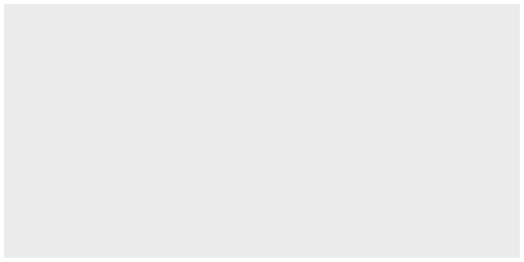

Figura 6: Inicialización de un objeto `ggplot`

## Mapeo

```r
ggplot(
  data = saber_pro_genericas_faedis_2021_2024,
  mapping = aes(y = estu_prgm_academico)
)
```

- ¿Por qué no utilizando la coordenada `x`?

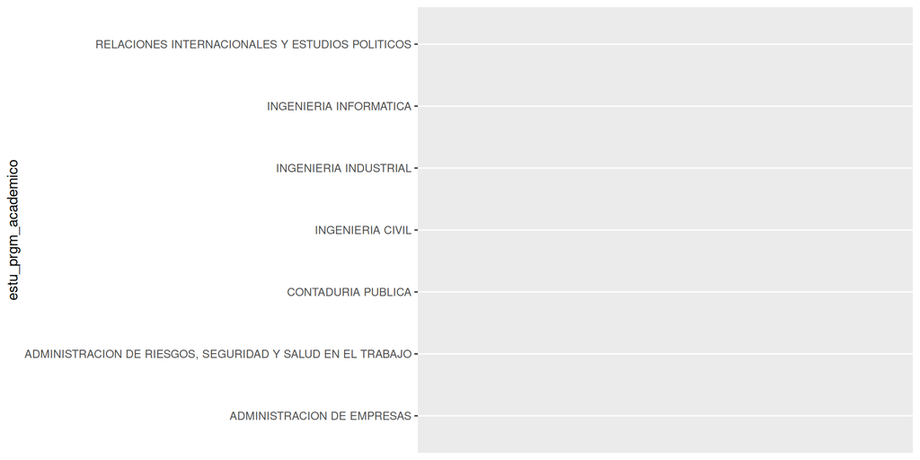

Figura 7: Mapeo de datos hacia atributos estéticos utilizando la coordenada `y`

## Capas

```r
ggplot(
  data = saber_pro_genericas_faedis_2021_2024,
  mapping = aes(y = estu_prgm_academico)
) +
  geom_bar()

ggplot(
  data = saber_pro_genericas_faedis_2021_2024,
  mapping = aes(
    y = fct_infreq(estu_prgm_academico)
  )
) +
  geom_bar()

ggplot(
  data = saber_pro_genericas_faedis_2021_2024,
  mapping = aes(
    y = fct_rev(
      fct_infreq(estu_prgm_academico)
    )
  )
) +
  geom_bar()
```

- Geometrías<sup>1</sup>

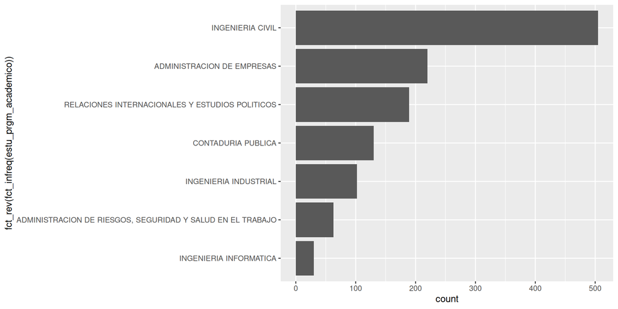

Figura 8: Uso de una geometría para ilustrar gráficamente datos a través de un atributo estético

[^1]: No utilizaremos por ahora transformaciones estadísticas y ajustes de posición.

## Escalas

```r
ggplot(
  data = saber_pro_genericas_faedis_2021_2024,
  mapping = aes(
    y = fct_rev(
      fct_infreq(estu_prgm_academico)
    )
  )
) +
  geom_bar() +
  scale_y_discrete(
    labels = label_wrap_gen(width = 18)
  )
```

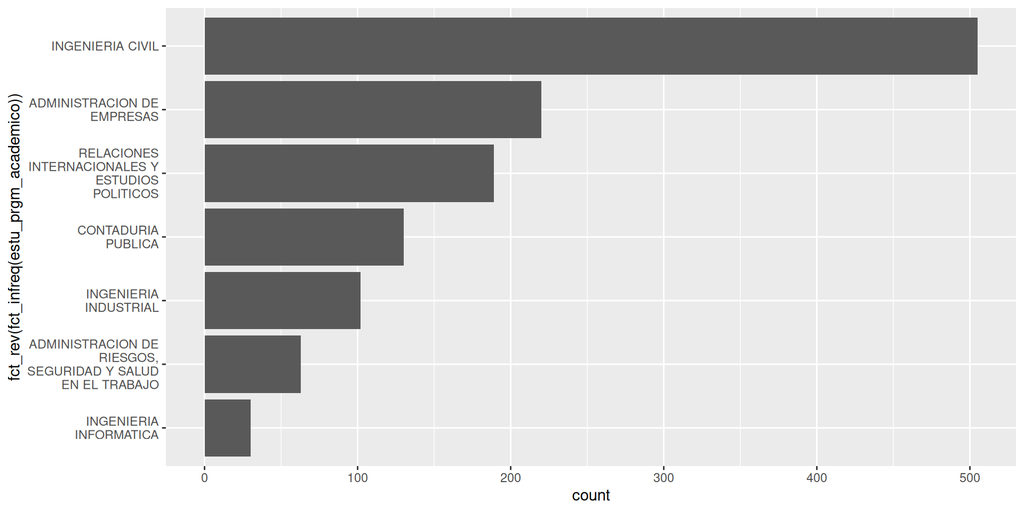

Figura 9: Uso de una escala para modificar las etiquetas en la coordenada `y`

## Escalas

```r
ggplot(
  data = saber_pro_genericas_faedis_2021_2024,
  mapping = aes(
    y = fct_rev(
      fct_infreq(estu_prgm_academico)
    )
  )
) +
  geom_bar() +
  scale_y_discrete(
    labels = label_wrap_gen(width = 18)
  ) +
  labs(
    x = "Número de inscritos",
    y = NULL,
    title = "Inscritos Saber Pro por programa en FAEDIS",
    subtitle = "Periodo: 2021 - 2024",
    caption = "Fuente: Data Icfes"
  )
```

- Etiquetas

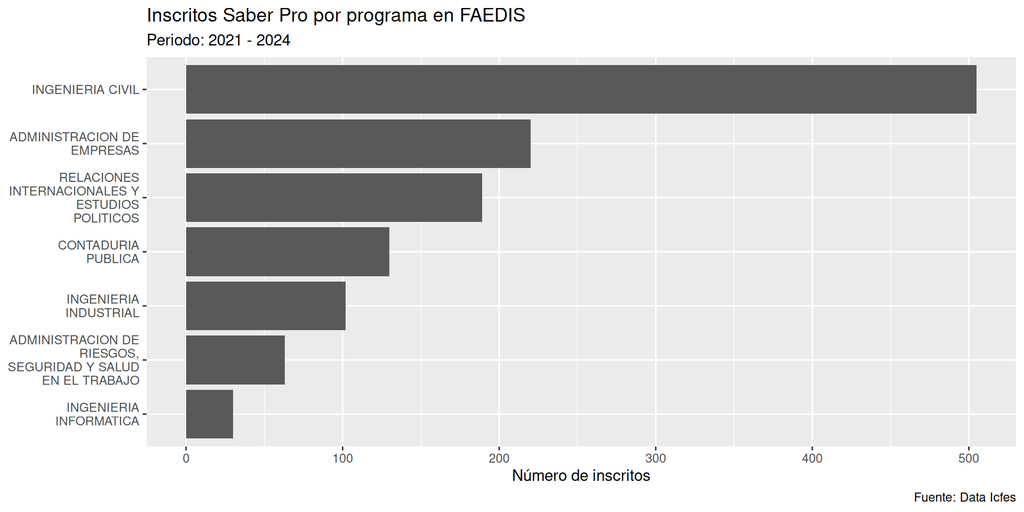

Figura 10: Uso de la función `labs()` para agregar, modificar o eliminar etiquetas en un gráfico

# Histograma

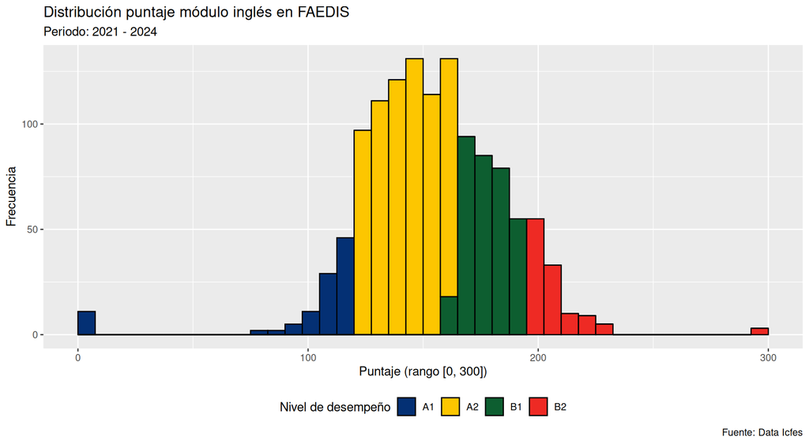

Figura 11: Resultado final de un histograma utilizando `ggplot2`

## Datos

```r
# Cargar paquetes ----
library(tidyverse)

# Importar datos ----
saber_pro_genericas_faedis_2021_2024 <- read_rds(
  file = "data/2021-2024_saber-pro-genericas_faedis.rds"
)

# Inspeccionar datos ----
glimpse(saber_pro_genericas_faedis_2021_2024)
```

```
Rows: 1,239
Columns: 21
$ ano                         <int> 2021, 2021, 2021, 2021, 2021, 2021, 2021, …
$ estu_consecutivo            <chr> "EK202120262469", "EK202120116785", "EK202…
$ estu_genero                 <fct> M, M, M, M, F, F, F, F, F, F, F, F, M, F, …
$ estu_semestrecursa          <ord> 09, 09, 09, 09, 09, 09, 08, 09, 08, 08, 10…
$ fami_estratovivienda        <ord> Estrato 3, Estrato 4, Estrato 5, Estrato 4…
$ fami_educacionmadre         <ord> Técnica o tecnológica incompleta, Postgrad…
$ fami_educacionpadre         <ord> Secundaria (Bachillerato) completa, Postgr…
$ estu_exterior               <chr> "NO", "NO", "NO", "NO", "NO", "NO", "NO", …
$ estu_cod_depto_presentacion <chr> "11", "11", "11", "11", "11", "11", "11", …
$ estu_depto_presentacion     <chr> "BOGOTÁ", "BOGOTÁ", "BOGOTÁ", "BOGOTÁ", "B…
$ estu_cod_mcpio_presentacion <chr> "11001", "11001", "11001", "11001", "11001…
$ estu_mcpio_presentacion     <chr> "BOGOTÁ D.C.", "BOGOTÁ D.C.", "BOGOTÁ D.C.…
$ estu_snies_prgmacademico    <int> 6527, 11428, 11428, 11428, 11428, 11428, 6…
$ estu_prgm_academico         <chr> "ADMINISTRACION DE EMPRESAS", "CONTADURIA …
$ mod_competen_ciudada_punt   <dbl> 162, 190, 154, 179, 178, 139, 143, 165, 12…
$ mod_comuni_escrita_punt     <dbl> 133, 174, 85, 157, 154, 131, 146, 137, 170…
$ mod_ingles_punt             <dbl> 151, 155, 150, 144, 142, 124, 162, 139, 11…
$ mod_ingles_desem            <ord> A2, A2, A2, A2, A2, A2, A2, A2, A1, A2, A2…
$ mod_lectura_critica_punt    <dbl> 114, 168, 139, 148, 188, 146, 161, 128, 12…
$ mod_razona_cuantitat_punt   <dbl> 135, 164, 113, 149, 166, 172, 143, 156, 12…
$ punt_global                 <dbl> 139, 170, 128, 155, 166, 142, 151, 145, 13…
```

## Mapeos y capas

```r
# Visualizar ----
ggplot(
  data = saber_pro_genericas_faedis_2021_2024,
  mapping = aes(x = mod_ingles_punt)
) +
  geom_histogram()
```

- Mensaje respecto al número de contenedores (`bins`)

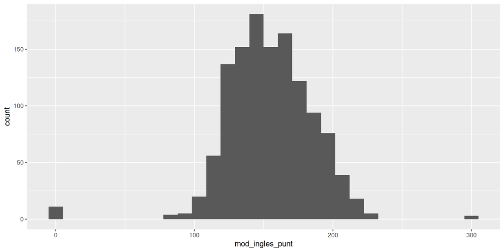

Figura 12: Uso de mapeo y una geometría para ilustrar gráficamente la distribución de una variable numérica

## Mapeos y capas

```r
ggplot(
  data = saber_pro_genericas_faedis_2021_2024,
  mapping = aes(x = mod_ingles_punt)
) +
  geom_histogram(
    boundary = 0,
    bins = 40,
    color = "black",
    fill = "yellow"
  )
```

- `color` y `fill` por fuera de `aes()`

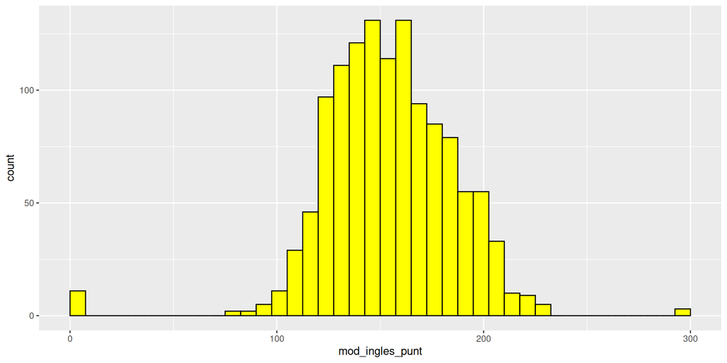

Figura 13: Asignación de colores por fuera de `aes()` para los atributos estéticos `color` y `fill` en una geometría asociada con un histograma

## Mapeos y capas

```r
ggplot(
  data = saber_pro_genericas_faedis_2021_2024,
  mapping = aes(x = mod_ingles_punt)
) +
  geom_histogram(
    mapping = aes(fill = mod_ingles_desem),
    boundary = 0,
    bins = 40,
    color = "black"
  )
```

- `fill` por dentro de `aes()`

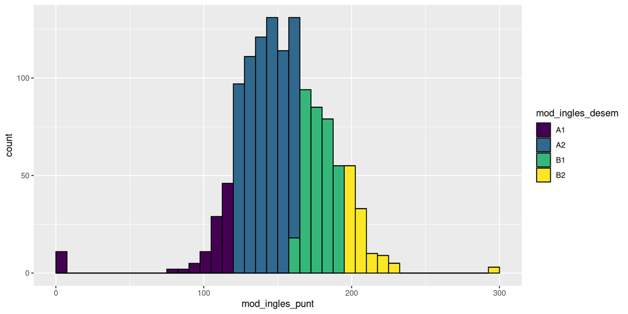

Figura 14: Asignación de colores dentro de `aes()` para el atributo estético `fill` en una geometría asociada con un histograma

## Escalas

```r
# Paleta primaria UMNG ----
paleta_primaria_umng <- c(
  "#043074",
  "#fdc600",
  "#0d5e30",
  "#ee2a24",
  "#000000",
  "#ffffff"
)
```

- Paleta de colores primaria UMNG

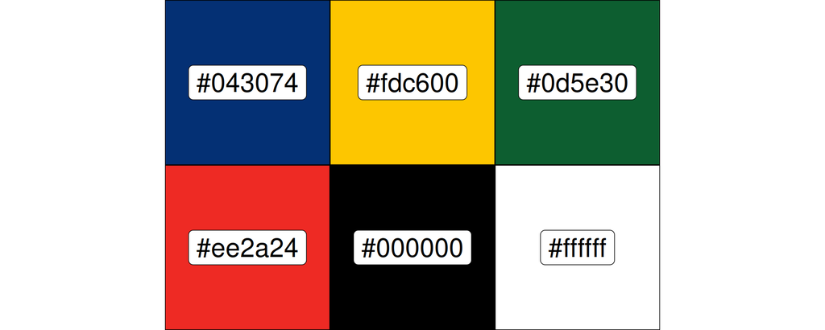

Figura 15: Paleta de colores primaria de la Universidad Militar Nueva Granada (UMNG) de acuerdo al Manual de Identidad Visual (UMNG 2024)

- Representación hexadecimal de colores
  - Ver (W3Schools 2026)

## Escalas

```r
ggplot(
  data = saber_pro_genericas_faedis_2021_2024,
  mapping = aes(x = mod_ingles_punt)
) +
  geom_histogram(
    mapping = aes(fill = mod_ingles_desem),
    boundary = 0,
    bins = 40,
    color = "black"
  ) +
  scale_fill_manual(
    values = paleta_primaria_umng[1:4]
  )
```

- Personalización paleta de colores

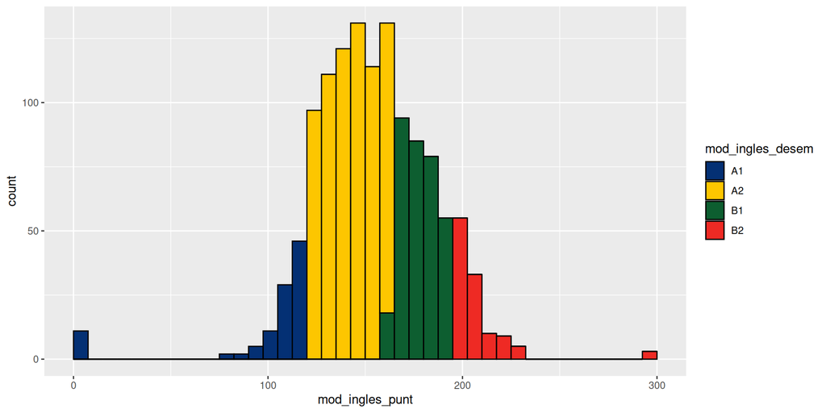

Figura 16: Personalización de la paleta de colores asociada al atributo estético `fill` dentro de `aes()` en una geometría

## Escalas

```r
ggplot(
  data = saber_pro_genericas_faedis_2021_2024,
  mapping = aes(x = mod_ingles_punt)
) +
  geom_histogram(
    mapping = aes(fill = mod_ingles_desem),
    color = "black",
    boundary = 0,
    bins = 40
  ) +
  scale_fill_manual(
    values = paleta_primaria_umng[1:4]
  ) +
  labs(
    x = "Puntaje (rango [0, 300])",
    y = "Frecuencia",
    fill = "Nivel de desempeño",
    title = "Distribución puntaje módulo inglés en FAEDIS",
    subtitle = "Periodo: 2021 - 2024",
    caption = "Fuente: Data Icfes"
  )
```

- Etiquetas

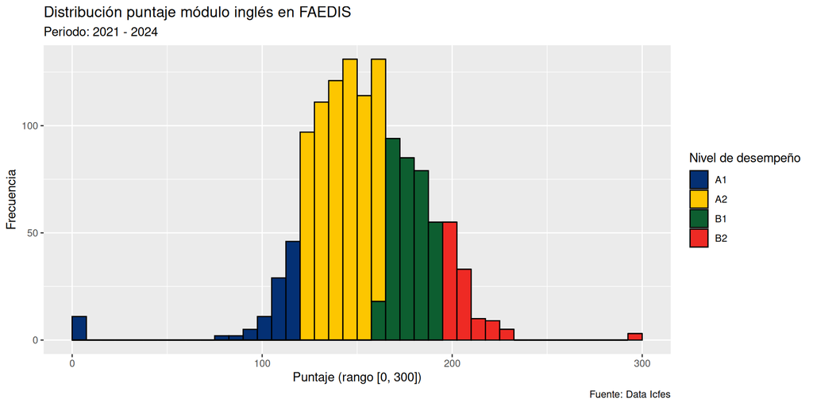

Figura 17: Personalización de la paleta de colores asociada al atributo estético `fill` dentro de `aes()` en una geometría

## Tema

```r
ggplot(
  data = saber_pro_genericas_faedis_2021_2024,
  mapping = aes(x = mod_ingles_punt)
) +
  geom_histogram(
    mapping = aes(fill = mod_ingles_desem),
    color = "black",
    boundary = 0,
    bins = 40
  ) +
  scale_fill_manual(
    values = paleta_primaria_umng[1:4]
  ) +
  labs(
    x = "Puntaje (rango [0, 300])",
    y = "Frecuencia",
    fill = "Nivel de desempeño",
    title = "Distribución puntaje módulo inglés en FAEDIS",
    subtitle = "Periodo: 2021 - 2024",
    caption = "Fuente: Data Icfes"
  ) +
  theme(
    legend.position = "bottom"
  )
```

- Modificación de la posición de la leyenda

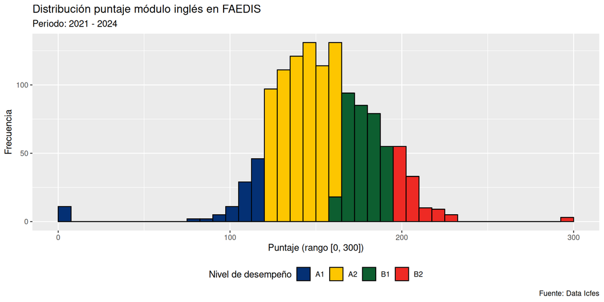

Figura 18: Uso de la función `theme()` para modificar la posición de una leyenda

Gracias

# Referencias

Khayrullin, Ilnur. 2026. «How to draw a rhino from the front view: realistic rhino drawing». En *Sketchok Easy Drawing Guides*. https://sketchok.com/animals/wild-animals/how-to-draw-a-rhino-from-the-front-view-realistic-rhino-drawing/.

UMNG. 2024. *Manual de Identidad Visual*. https://umng.edu.co/wp-content/uploads/2026/04/Manual_Identidad_Visual_UMNG-sep-2024.pdf.

W3Schools. 2026. *HTML HEX and HEXA Colors*. https://www.w3schools.com/html/html_colors_hex.asp.

Wilkinson, Leland, y Graham Wills. 2005. *The grammar of graphics*. 2nd ed. Statistics y computing. Springer.